# Reproducible Research Course Project 1

Sha Li

December 24, 2016

### 1. Code for reading in the dataset and/or processing the data

```r
library(ggplot2)
activity<-read.csv("activity.csv")
```

### 2. Histogram of the total number of steps taken each day

Calculate total steps taken per day, missing value is ignored.

```r
totalSteps<-aggregate(activity$steps, list(Date=activity$date), FUN=sum)
totalSteps$Date<-as.Date(totalSteps$Date, format="%Y-%m-%d")
```

Plot a histogram of total steps taken per day.

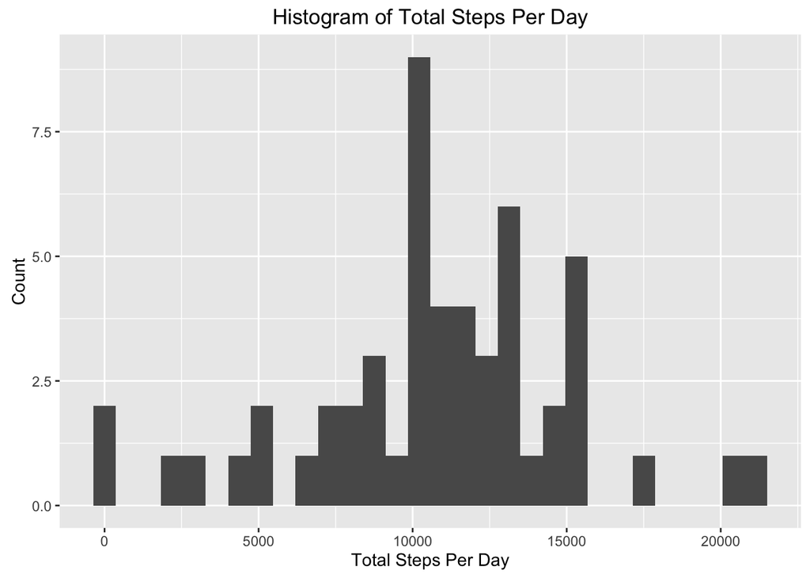

```r
qplot(x, data = totalSteps, xlab = "Total Steps Per Day", ylab = "Count", main = "Histogram of Total Steps Per Day")
```

```r
dev.copy(png, file="figure1.png")
```

```r
dev.off()
```

### 3. Mean and median number of steps taken each day

```r
summary(totalSteps)
```

```
##       Date                  x
##  Min.   :2012-10-01   Min.   :   41
##  1st Qu.:2012-10-16   1st Qu.: 8841
##  Median :2012-10-31   Median :10765
##  Mean   :2012-10-31   Mean   :10766
##  3rd Qu.:2012-11-15   3rd Qu.:13294
##  Max.   :2012-11-30   Max.   :21194
##                       NA's   :8
```

```r
meanSteps<-mean(totalSteps$x, na.rm = TRUE)
medianSteps<-median(totalSteps$x, na.rm = TRUE)
```

### 4. Time series plot of the average number of steps taken

Plot time series graph that shows the average daily activity pattern, missing value is ignored.

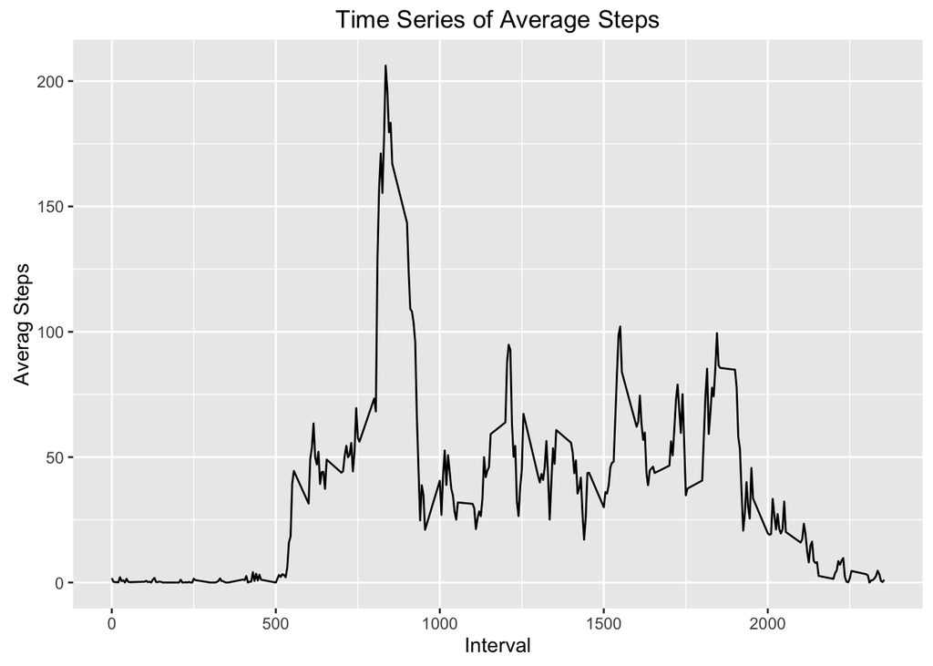

```r
meanPattern<-aggregate(activity$steps, list(Interval=activity$interval), FUN=mean, na.rm=TRUE)
ggplot(meanPattern, aes(Interval, x)) + geom_line() + xlab("Interval") + ylab("Averag Steps")+labs(title="Time Series of Average Steps")
```

```r
dev.copy(png, file="figure2.png")
```

```r
dev.off()
```

### 5. The 5-minute interval that, on average, contains the maximum number of steps

```r
summary(meanPattern)
```

```
##     Interval            x
##  Min.   :   0.0   Min.   :  0.000
##  1st Qu.: 588.8   1st Qu.:  2.486
##  Median :1177.5   Median : 34.113
##  Mean   :1177.5   Mean   : 37.383
##  3rd Qu.:1766.2   3rd Qu.: 52.835
##  Max.   :2355.0   Max.   :206.170
```

```r
intervalMax<-meanPattern[which.max(meanPattern$x),1]
```

Maximum number of steps 206.170 can be found when the 5-minute interval is 835.

### 6. Code to describe and show a strategy for imputing missing data

```r
summary(activity$steps)
```

```
##    Min. 1st Qu.  Median    Mean 3rd Qu.    Max.    NA's
##    0.00    0.00    0.00   37.38   12.00  806.00    2304
```

```r
missing<-sum(is.na(activity$steps))
```

There are 2304 NAs in the dataset.

```r
meanDaily<-mean(activity$steps, na.rm = TRUE)
activityNew<-as.data.frame(activity)
activityNew[is.na(activityNew)]<-meanDaily
```

A new data set is created with NAs replaced by 37.3825996.

### 7. Histogram of the total number of steps taken each day after missing values are imputed

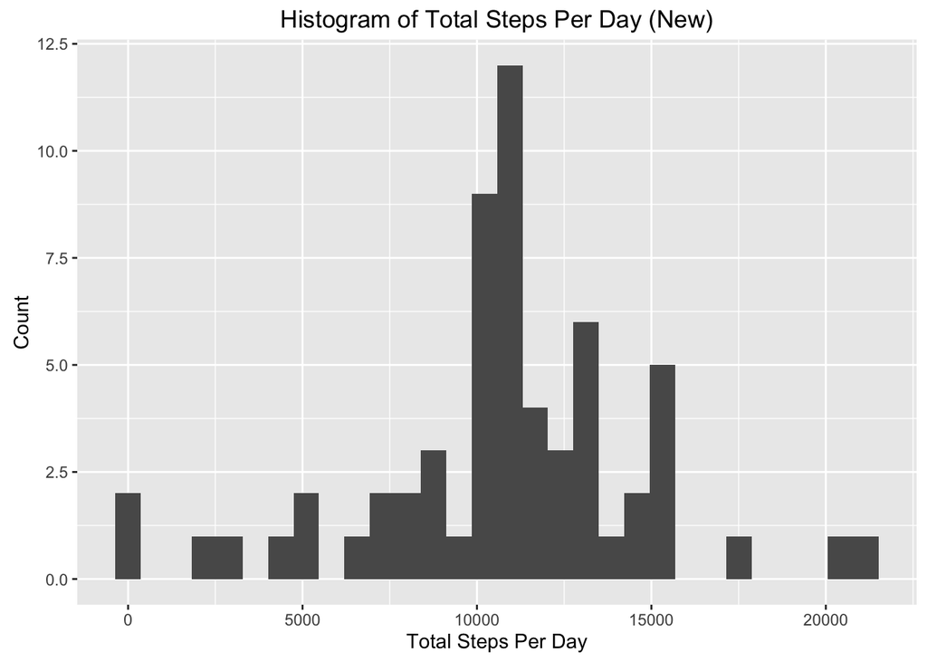

```r
totalStepsNew<-aggregate(activityNew$steps, list(Date=activityNew$date), FUN=sum)
totalStepsNew$Date<-as.Date(totalStepsNew$Date,format="%Y-%m-%d")
qplot(x,data = totalStepsNew,xlab = "Total Steps Per Day", ylab = "Count", main = "Histogram of Total Steps Per Day (New)")
```

```r
dev.copy(png, file="figure3.png")
```

```r
dev.off()
```

Calculate the new mean and median after imputing NAs.

```r
summary(totalStepsNew)
```

```
##       Date                  x
##  Min.   :2012-10-01   Min.   :   41
##  1st Qu.:2012-10-16   1st Qu.: 9819
##  Median :2012-10-31   Median :10766
##  Mean   :2012-10-31   Mean   :10766
##  3rd Qu.:2012-11-15   3rd Qu.:12811
##  Max.   :2012-11-30   Max.   :21194
```

```r
meanStepsNew<-round(mean(totalStepsNew$x))
medianStepsNew<-round(median(totalStepsNew$x))
```

### 8. Panel plot comparing the average number of steps taken per 5-minute interval across weekdays and weekends

Create a new factor variable in the dataset “activityNew” with two levels: “weekday” and “weekend”.

```r
dayEnd<-activityNew$date
dayEnd<-weekdays(as.Date(activityNew$date))
dayEnd[dayEnd %in% c("Monday","Tuesday","Wednesday","Thursday","Friday")]<-"Weekday"
dayEnd[dayEnd %in% c("Saturday","Sunday")]<-"Weekend"
dayEnd<-factor(dayEnd, labels = c("Weekday","Weekend"))
activityNew<-cbind(activityNew,dayEnd)
```

Calculate the average steps taken across all weekdays or weekends, plot two time series graphs on the condition of weekdays and weekends.

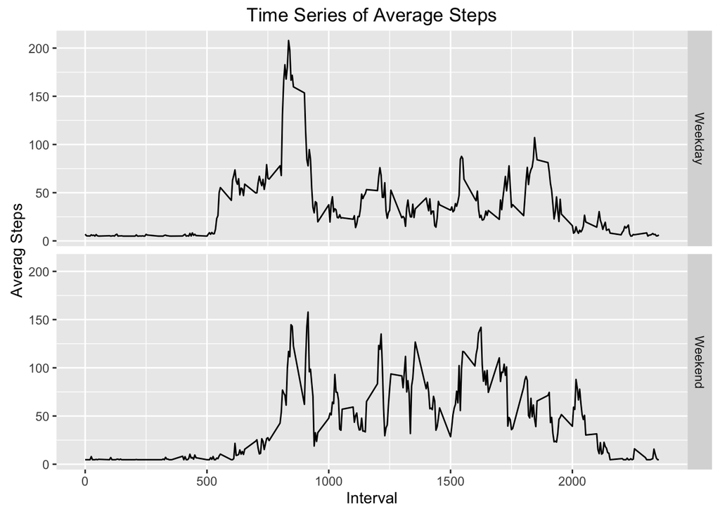

```r
meanPatternNew<-aggregate(activityNew$steps, list(Weekday=activityNew$dayEnd, Interval=activityNew$interval), FUN=mean)
ggplot(meanPatternNew, aes(Interval, x)) + geom_line() + xlab("Interval") + ylab("Averag Steps")+labs(title="Time Series of Average Steps")+facet_grid(Weekday~.)
```

```r
dev.copy(png, file="figure4.png")
```

```r
dev.off()
```

The graphs show the difference between weekday and weekend steps pattern, weekday has higher max steps than weekend during a specific time interval, however, weekeday has relatively less steps than weekend during other time intervals.